# Procesos de Markov a Tiempo Continuo: dos aplicaciones

Este cuaderno reúne dos aplicaciones de las **cadenas de Markov a tiempo continuo** (CTMC), pensadas para mostrar el mismo aparato matemático trabajando en dos escalas muy distintas:

1. **El camión repartidor** (cuatro estados, matriz generadora $Q$ explícita). Sirve para fijar las definiciones formales, el algoritmo de simulación de Gillespie, y dar intuición visual sobre tiempos exponenciales y trayectorias.
2. **El modelo SEIR estocástico** ($O(N^3)$ estados). Muestra el mismo aparato cuando el espacio de estados ya no cabe en una matriz: las tasas locales $q_{xy}$ describen la dinámica completa. Exhibe además fenómenos genuinamente estocásticos (extinción aleatoria, distribución del pico) que el SEIR determinista no captura.

En ambos casos seguimos la misma receta: definir el espacio de estados, escribir las tasas $q_{xy}$, simular vía Gillespie, y comparar con la trayectoria determinista cuando aplica.

# Procesos de Markov a Tiempo Continuo: El camión repartidor

## Motivación

Imagina que eres el gerente de una flotilla de camiones. Cada camión puede estar en distintas condiciones: funcionando bien, con el testigo de motor encendido, en el taller para mantenimiento rápido, o esperando una reparación más laboriosa. Lo que nos interesa es modelar cómo evoluciona el estado del camión a lo largo del tiempo, incluyendo cuánto tiempo pasa en cada estado y cómo transita entre ellos.

Para esto usaremos un Proceso de Markov a Tiempo Continuo. Esta es una generalización de las cadenas de Markov en tiempo discreto que ya conoces, con dos diferencias clave:

1. El tiempo es continuo: el proceso puede cambiar de estado en cualquier instante $t \in [0, \infty)$, no solo en pasos $n = 0, 1, 2, \ldots$
2. El tiempo de permanencia en cada estado es aleatorio: si el proceso está en el estado $i$, el tiempo que permanece ahí antes de saltar sigue una distribución Exponencial.

La propiedad de Markov sigue siendo la misma: el futuro solo depende del estado actual, no de la historia pasada.

## Los cuatro estados del camión

Modelamos el camión con el espacio de estados $\mathcal{S} = \{B, R, M, D\}$:

| Estado | Descripción |
| --- | --- |
| $B$ | Buen estado — operando normalmente |
| $R$ | En Riesgo — testigo de motor encendido |
| $M$ | En Mantenimiento preventivo — taller rápido |
| $D$ | Descompuesto — en reparación (taller lento) |

## Definición formal: la matriz generadora $Q$

Un CTMC queda completamente especificado por su matriz $Q$, cuyas entradas $q_{ij}$ se interpretan así:

- $q_{ij} \geq 0$ para $i \neq j$:tasa a la que el proceso salta del estado $i$ al estado $j$.
- $q_{ii} = -\sum_{j \neq i} q_{ij}$: negativo de la tasa total de salida del estado $i$.
- Toda fila de $Q$ suma cero: $\sum_j q_{ij} = 0$.

Para nuestro camión, con parámetros $\lambda, \alpha, \beta, \mu_1, \mu_2 > 0$, las únicas transiciones posibles son:

$$ B \xrightarrow{\lambda} R \qquad R \xrightarrow{\alpha} M \qquad R \xrightarrow{\beta} D \qquad M \xrightarrow{\mu_1} B \qquad D \xrightarrow{\mu_2} B $$

Ordenando los estados como $(B, R, M, D)$, la matriz $Q$ es:

$$ Q = \begin{pmatrix} -\lambda & \lambda & 0 & 0 \\ 0 & -(\alpha+\beta) & \alpha & \beta \\ \mu_1 & 0 & -\mu_1 & 0 \\ \mu_2 & 0 & 0 & -\mu_2 \end{pmatrix} $$

Nótese que las filas suman cero y todas las entradas fuera de la diagonal son no negativas, como debe ser.

```python
import numpy as np

# Parámetros del modelo (valores por defecto)
lam = 0.3
alp = 0.5
bet = 0.1
mu1 = 1.2
mu2 = 0.4

# Orden de estados
estados = ['B', 'R', 'M', 'D']
n = len(estados)

# Construcción de Q
Q = np.zeros((n, n))
Q[0, 1] = lam
Q[1, 2] = alp
Q[1, 3] = bet
Q[2, 0] = mu1
Q[3, 0] = mu2

# La diagonal se define como el negativo de la suma de cada fila
np.fill_diagonal(Q, -Q.sum(axis=1))
```

## Simulación de trayectorias

Para simular una trayectoria del CTMC usamos el siguiente algoritmo, que se sigue directamente de la estructura del proceso:

### Algoritmo de simulación

Dado el estado actual $i$ y la matriz $Q$:

1. Tiempo de permanencia: el proceso permanece en el estado $i$ durante un tiempo aleatorio $\tau \sim \text{Exp}(-q_{ii})$.
2. Siguiente estado: una vez que el proceso decide salir, elige el estado $j \neq i$ al que saltar con probabilidad: $$P_{ij}= \frac{q_{ij}}{|q_{ii}|}$$
3. Actualización: avanza el reloj en $\tau$, actualiza el estado a $j$, y repite desde el paso 1 hasta alcanzar el horizonte de tiempo $T$.

```python
def simular_ctmc(Q, estado_inicial, T, semilla=None):
    if semilla is not None:
        np.random.seed(semilla)

    etiquetas = ['B', 'R', 'M', 'D']
    n = Q.shape[0]

    # Permitir estado_inicial como string ('B','R','M','D') o como índice entero
    if isinstance(estado_inicial, str):
        estado_inicial = etiquetas.index(estado_inicial)

    # Listas de resultados: empezamos en t=0 con el estado inicial
    tiempos = [0.0]
    estados = [etiquetas[estado_inicial]]

    t_actual   = 0.0
    i_actual   = estado_inicial

    while t_actual < T:
        # Paso 1: tasa total de salida del estado actual
        tasa_salida = -Q[i_actual, i_actual]

        # Si la tasa de salida es cero, el estado es absorbente: terminamos
        if tasa_salida == 0:
            break

        # Paso 2: tiempo de permanencia ~ Exp(tasa_salida)
        tau = np.random.exponential(scale=1.0 / tasa_salida)

        # Si nos pasamos del horizonte, registramos el tiempo final y salimos
        if t_actual + tau > T:
            tiempos.append(T)
            estados.append(etiquetas[i_actual])   # el estado no cambia
            break

        # Avanzamos el tiempo
        t_actual += tau

        # Paso 3: elegir el siguiente estado

        # Normalizamos para obtener probabilidades de transición
        tasas_destino = Q[i_actual].copy()
        tasas_destino[i_actual] = 0.0
        probs = tasas_destino / tasa_salida

        # Muestreamos el siguiente estado
        i_siguiente = np.random.choice(n, p=probs)

        # Registramos el salto
        tiempos.append(t_actual)
        estados.append(etiquetas[i_siguiente])
        i_actual = i_siguiente

    return tiempos, estados
```

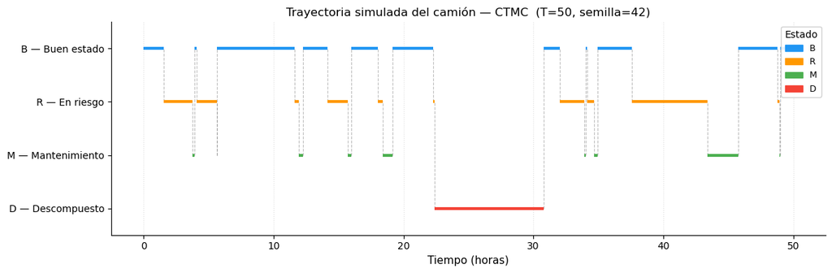

```
 Resumen de la trayectoria simulada:

  B: 22.76 horas  (45.5%)
  R: 14.52 horas  (29.0%)
  M: 4.29 horas  (8.6%)
  D: 8.43 horas  (16.9%)
  Total de saltos: 30
```

```python
import matplotlib.pyplot as plt
import matplotlib.patches as mpatches

# Simulación
T_horizonte   = 50
estado_inicial = 0    # Comienza en B
semilla_fija   = 42

tiempos, estados_sim = simular_ctmc(
    Q, estado_inicial, T_horizonte, semilla=semilla_fija
)

# Codificación numérica para el eje Y
cod = {'B': 3, 'R': 2, 'M': 1, 'D': 0}
y_vals = [cod[e] for e in estados_sim]

# Colores por estado
color_estado = {
    'B': '#2196F3',
    'R': '#FF9800',
    'M': '#4CAF50',
    'D': '#F44336',
}

# Gráfica
fig, ax = plt.subplots(figsize=(12, 4))

for k in range(len(tiempos) - 1):
    t_ini  = tiempos[k]
    t_fin  = tiempos[k + 1]
    estado = estados_sim[k]
    y      = y_vals[k]
    color  = color_estado[estado]

    ax.hlines(y=y, xmin=t_ini, xmax=t_fin,
              colors=color, linewidths=3)

    if k + 1 < len(tiempos) - 1:
        ax.vlines(x=t_fin, ymin=min(y, y_vals[k+1]),
                  ymax=max(y, y_vals[k+1]),
                  colors='gray', linewidths=0.8, linestyles='--', alpha=0.5)

ax.set_yticks([0, 1, 2, 3])
ax.set_yticklabels(['D — Descompuesto', 'M — Mantenimiento',
                    'R — En riesgo', 'B — Buen estado'], fontsize=10)
ax.set_ylim(-0.5, 3.5)

parches = [mpatches.Patch(color=color_estado[e], label=e) for e in ['B','R','M','D']]
ax.legend(handles=parches, title='Estado', loc='upper right',
          framealpha=0.9, fontsize=9)

ax.set_xlabel('Tiempo (horas)', fontsize=11)
ax.set_title(
    f'Trayectoria simulada del camión — CTMC  '
    f'(T={T_horizonte}, semilla={semilla_fija})',
    fontsize=12
)
ax.grid(axis='x', linestyle=':', alpha=0.4)
ax.spines[['top', 'right']].set_visible(False)

plt.tight_layout()
plt.show()

# Resumen de la simulación
print("\n Resumen de la trayectoria simulada: \n")
duraciones = {e: 0.0 for e in ['B', 'R', 'M', 'D']}
for k in range(len(tiempos) - 1):
    duraciones[estados_sim[k]] += tiempos[k+1] - tiempos[k]

for e, dur in duraciones.items():
    print(f"  {e}: {dur:.2f} horas  ({100*dur/T_horizonte:.1f}%)")
print(f"  Total de saltos: {len(tiempos) - 2}")
```

## Panel interactivo

Este panel te permite explorar el comportamiento del modelo. Mueve cualquier slider y genera simulaciones las veces que quieras.

### Controles

| Slider | Significado |
| --- | --- |
| $\lambda$ | Tasa de desgaste $B \to R$ |
| $\alpha$ | Tasa de atención $R \to M$ (conductor nota el testigo) |
| $\beta$ | Tasa de descompostura $R \to D$ |
| $\mu_1$ | Tasa de recuperación $M \to B$ |
| $\mu_2$ | Tasa de reparación $D \to B$ |
| $T$ | Horizonte de simulación (horas) |
| Semilla | Semilla aleatoria (misma semilla = misma trayectoria) |

```python
# ── Dependencias ──────────────────────────────────────────────────────────────
%matplotlib inline
import numpy as np
import matplotlib.pyplot as plt
import matplotlib.patches as mpatches
import matplotlib.animation as animation
import ipywidgets as widgets
from IPython.display import display, clear_output, Image as IPImage

# ── Constantes fijas ───────────────────────────────────────────────────────────
T_DIAS       = 150     # horizonte temporal fijo
N_FRAMES     = 80      # frames del GIF
DURACION_MS  = 10_000  # duración total: 10 segundos
INTERVALO_MS = DURACION_MS // N_FRAMES   # ms por frame

# ── Paleta de colores (B=verde, R=naranja, M=azul, D=rojo) ────────────────────
COLOR = {
    'B': '#4CAF50',
    'R': '#FF9800',
    'M': '#2196F3',
    'D': '#F44336',
}
ESTADOS = ['B', 'R', 'M', 'D']

# ── Función auxiliar: construir Q ─────────────────────────────────────────────
def construir_Q(lam, alpha, beta, mu1, mu2):
    """Devuelve la matriz generadora 4x4 con orden [B, R, M, D]."""
    return np.array([
        [-lam,          lam,    0.0,    0.0],
        [ 0.0, -(alpha+beta),  alpha,   beta],
        [ mu1,          0.0,  -mu1,    0.0],
        [ mu2,          0.0,   0.0,   -mu2],
    ])

# ── Formato del eje ────────────────────────────────────────────────────────────
def formatear_eje(ax):
    ax.set_yticks([0, 1, 2, 3])
    ax.set_yticklabels(
        ['D — Descompuesto', 'M — Mantenimiento', 'R — En riesgo', 'B — Buen estado'],
        fontsize=9
    )
    ax.set_ylim(-0.5, 3.5)
    ax.set_xlim(0, T_DIAS)
    ax.set_xlabel('Tiempo (días)', fontsize=10)
    ax.grid(axis='x', linestyle=':', alpha=0.35)
    ax.spines[['top', 'right']].set_visible(False)
    parches = [mpatches.Patch(color=COLOR[e], label=e) for e in ESTADOS]
    ax.legend(handles=parches, title='Estado', loc='upper right',
              framealpha=0.85, fontsize=8)

# ── Trayectoria estática (al mover sliders) ────────────────────────────────────
def dibujar_estatico(lam, alpha, beta, mu1, mu2):
    semilla = np.random.randint(0, 10000)
    Q       = construir_Q(lam, alpha, beta, mu1, mu2)
    tiempos, estados_sim = simular_ctmc(Q, 'B', float(T_DIAS), semilla=semilla)
    cod = {'B': 3, 'R': 2, 'M': 1, 'D': 0}

    fig, ax = plt.subplots(figsize=(13, 4))
    formatear_eje(ax)

    for k in range(len(tiempos) - 1):
        y     = cod[estados_sim[k]]
        color = COLOR[estados_sim[k]]
        ax.hlines(y=y, xmin=tiempos[k], xmax=tiempos[k+1],
                  colors=color, linewidths=3.5)
        if k + 1 < len(tiempos) - 1:
            y_sig = cod[estados_sim[k+1]]
            ax.vlines(x=tiempos[k+1],
                      ymin=min(y, y_sig), ymax=max(y, y_sig),
                      colors='gray', linewidths=0.9, linestyles='--', alpha=0.5)

    ax.set_title('Panel interactivo — CTMC Camión repartidor',
                 fontsize=13, fontweight='bold', pad=10)
    fig.subplots_adjust(left=0.20, right=0.97, top=0.88, bottom=0.15)
    plt.show()

# ── GIF animado en loop (al presionar el botón) ────────────────────────────────
def generar_gif(lam, alpha, beta, mu1, mu2):
    """
    Genera la trayectoria progresiva como GIF animado en loop.
    Pillow escribe cada frame en un buffer en memoria; no se escribe
    ningún archivo en disco. El GIF se muestra con IPython.display.Image.
    """
    semilla = np.random.randint(0, 10000)
    Q       = construir_Q(lam, alpha, beta, mu1, mu2)
    tiempos, estados_sim = simular_ctmc(Q, 'B', float(T_DIAS), semilla=semilla)
    cod = {'B': 3, 'R': 2, 'M': 1, 'D': 0}

    n_seg         = len(tiempos) - 1
    indices_frame = np.linspace(0, n_seg, N_FRAMES + 1, dtype=int)

    fig, ax = plt.subplots(figsize=(13, 4))

    # Configurar el eje UNA sola vez antes de la animación
    formatear_eje(ax)
    seg_anterior = [0]  # mutables para acceder desde update()

    def init():
        return []

    def update(fi):
        seg_hasta = indices_frame[fi]
        # Solo dibujar los segmentos NUEVOS (no redibujar los anteriores)
        for k in range(seg_anterior[0], seg_hasta):
            y     = cod[estados_sim[k]]
            color = COLOR[estados_sim[k]]
            ax.hlines(y=y, xmin=tiempos[k], xmax=tiempos[k+1],
                      colors=color, linewidths=3.5)
            if k + 1 < len(tiempos) - 1:
                y_sig = cod[estados_sim[k+1]]
                ax.vlines(x=tiempos[k+1],
                          ymin=min(y, y_sig), ymax=max(y, y_sig),
                          colors='gray', linewidths=0.9, linestyles='--', alpha=0.5)
        seg_anterior[0] = seg_hasta
        return []

    anim = animation.FuncAnimation(
        fig, update,
        frames=N_FRAMES + 1,
        init_func=init,
        interval=INTERVALO_MS,
    )

    ax.set_title('Panel interactivo — CTMC Camión repartidor',
                 fontsize=13, fontweight='bold', pad=10)
    fig.subplots_adjust(left=0.20, right=0.97, top=0.88, bottom=0.15)

    # Guardar en archivo temporal (esta versión de matplotlib no acepta BytesIO)
    import tempfile, os
    tmp = tempfile.NamedTemporaryFile(suffix='.gif', delete=False)
    tmp_path = tmp.name
    tmp.close()

    anim.save(tmp_path, writer='pillow', fps=N_FRAMES // (DURACION_MS // 1000))
    plt.close(fig)

    # Leer los bytes y mostrar el GIF; luego eliminar el archivo temporal
    with open(tmp_path, 'rb') as f:
        gif_bytes = f.read()
    os.unlink(tmp_path)

    display(IPImage(data=gif_bytes, format='gif'))

# ── Sliders de tasas ───────────────────────────────────────────────────────────
sl_lam = widgets.FloatSlider(value=0.3, min=0.05, max=2.0, step=0.05,
                              description='λ (B→R)',
                              style={'description_width': '80px'},
                              layout=widgets.Layout(width='320px'))
sl_alp = widgets.FloatSlider(value=0.5, min=0.05, max=2.0, step=0.05,
                              description='α (R→M)',
                              style={'description_width': '80px'},
                              layout=widgets.Layout(width='320px'))
sl_bet = widgets.FloatSlider(value=0.1, min=0.05, max=2.0, step=0.05,
                              description='β (R→D)',
                              style={'description_width': '80px'},
                              layout=widgets.Layout(width='320px'))
sl_mu1 = widgets.FloatSlider(value=1.2, min=0.05, max=2.0, step=0.05,
                              description='μ₁ (M→B)',
                              style={'description_width': '80px'},
                              layout=widgets.Layout(width='320px'))
sl_mu2 = widgets.FloatSlider(value=0.4, min=0.05, max=2.0, step=0.05,
                              description='μ₂ (D→B)',
                              style={'description_width': '80px'},
                              layout=widgets.Layout(width='320px'))

# ── Botón minimalista ──────────────────────────────────────────────────────────
btn_nueva = widgets.Button(
    description='Nueva simulación',
    button_style='',
    tooltip='Genera un nuevo GIF animado en loop',
    layout=widgets.Layout(width='148px', height='28px'),
    style=widgets.ButtonStyle(font_size='12px'),
)

# ── Widgets de salida separados: uno para la gráfica, uno para el botón ───────
# Así el botón siempre queda debajo de la animación, sin desaparecer al
# limpiar la salida de la gráfica.
out_grafica = widgets.Output()
out_boton   = widgets.Output()

# ── Callbacks ─────────────────────────────────────────────────────────────────
def actualizar_estatico(change):
    """Al mover cualquier slider: trayectoria estática."""
    with out_grafica:
        clear_output(wait=True)
        dibujar_estatico(
            lam=sl_lam.value, alpha=sl_alp.value, beta=sl_bet.value,
            mu1=sl_mu1.value, mu2=sl_mu2.value,
        )

def nueva_simulacion(_):
    """Al presionar el botón: GIF animado en loop."""
    with out_grafica:
        clear_output(wait=True)
        generar_gif(
            lam=sl_lam.value, alpha=sl_alp.value, beta=sl_bet.value,
            mu1=sl_mu1.value, mu2=sl_mu2.value,
        )

for sl in [sl_lam, sl_alp, sl_bet, sl_mu1, sl_mu2]:
    sl.observe(actualizar_estatico, names='value')

btn_nueva.on_click(nueva_simulacion)

# ── Layout: sliders arriba, animación en medio, botón abajo ───────────────────
col_izq = widgets.VBox(
    [sl_lam, sl_alp, sl_bet],
    layout=widgets.Layout(margin='0 24px 0 0')
)
col_der = widgets.VBox([sl_mu1, sl_mu2])

controles = widgets.HBox([col_izq, col_der])

# Botón centrado debajo de la animación
fila_boton = widgets.HBox(
    [btn_nueva],
    layout=widgets.Layout(justify_content='center', margin='6px 0 0 0')
)

panel = widgets.VBox(
    [controles, out_grafica, fila_boton],
    layout=widgets.Layout(padding='10px')
)

# ── Primer render al ejecutar la celda ────────────────────────────────────────
display(panel)
actualizar_estatico(None)
```

```
VBox(children=(HBox(children=(VBox(children=(FloatSlider(value=0.3, description='λ (B→R)', layout=Layout(width…
```

## ¿Qué decisiones puedo tomar con esto?

El CTMC no es sólo una descripción del camión: permite responder preguntas operativas con números. La pieza clave es la **distribución estacionaria** $\pi$, la única solución de $\pi Q = 0$ con $\sum_i \pi_i = 1$. Su interpretación es directa:

> $\pi_i$ es la **fracción del tiempo** que el camión pasa en el estado $i$ a largo plazo.

Con eso podemos contestar tres preguntas que un gerente de flotilla se hace todos los días:

1. **¿Cuánto tiempo opera el camión?** $\pi_B$ es el porcentaje de horas productivas; $\pi_D$ es el tiempo perdido en reparaciones pesadas.
2. **¿Vale la pena revisar más rápido los testigos encendidos?** El parámetro $\alpha$ (tasa $R \to M$) controla qué tan rápido mando el camión al taller cuando aparece el testigo. Subir $\alpha$ baja $\pi_D$.
3. **¿Cuánto cuesta no atenderlo?** La diferencia de $\pi_D$ entre dos valores de $\alpha$ se traduce inmediatamente en horas perdidas y dinero.

Abajo calculamos $\pi$ y mostramos cómo cambia $\pi_D$ al variar $\alpha$.

```
Distribución estacionaria (parámetros actuales):
  π_B =  54.5%
  π_R =  27.3%
  π_M =  11.4%
  π_D =   6.8%
```

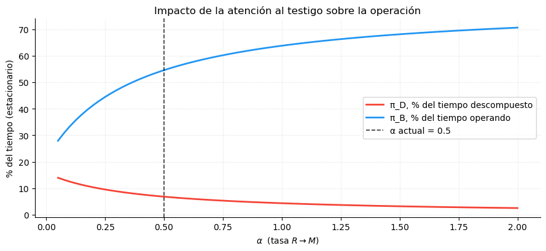

```
Comparación de políticas:
      α    π_B (%)    π_D (%)    horas/año descompuesto
    0.2       41.4       10.3                   906  (lento)
    0.5       54.5        6.8                   597  (actual)
    1.0       63.8        4.3                   381  (agresivo)
```

```python
def estacionaria(Q):
    """Resuelve pi Q = 0 con sum(pi) = 1 (sistema lineal con restricción)."""
    n = Q.shape[0]
    A = np.vstack([Q.T, np.ones(n)])
    b = np.zeros(n + 1)
    b[-1] = 1.0
    pi, *_ = np.linalg.lstsq(A, b, rcond=None)
    return pi


# 1) Distribución estacionaria con los parámetros actuales
pi_actual = estacionaria(Q)
print('Distribución estacionaria (parámetros actuales):')
for e, p in zip(estados, pi_actual):
    print(f'  π_{e} = {100*p:5.1f}%')

# 2) Sensibilidad: cómo cambia π_D al variar α (tasa R → M)
alphas = np.linspace(0.05, 2.0, 80)
pi_D = np.empty_like(alphas)
pi_B = np.empty_like(alphas)
for k, a in enumerate(alphas):
    Qa = Q.copy()
    Qa[1, 2] = a
    Qa[1, 1] = -(a + bet)
    pi_a = estacionaria(Qa)
    pi_B[k], pi_D[k] = pi_a[0], pi_a[3]

fig, ax = plt.subplots(figsize=(9, 4.2))
ax.plot(alphas, 100*pi_D, color='#F44336', lw=2,
        label='π_D, % del tiempo descompuesto')
ax.plot(alphas, 100*pi_B, color='#2196F3', lw=2,
        label='π_B, % del tiempo operando')
ax.axvline(alp, color='black', ls='--', lw=1.2, alpha=0.8,
           label=f'α actual = {alp}')
ax.set_xlabel(r'$\alpha$  (tasa $R \to M$)')
ax.set_ylabel('% del tiempo (estacionario)')
ax.set_title('Impacto de la atención al testigo sobre la operación')
ax.legend()
ax.grid(linestyle=':', alpha=0.4)
ax.spines[['top', 'right']].set_visible(False)
plt.tight_layout()
plt.show()

# 3) Comparación numérica: tres políticas concretas
print('\nComparación de políticas:')
print(f'  {"α":>5}  {"π_B (%)":>9}  {"π_D (%)":>9}  {"horas/año descompuesto":>24}')
HORAS_AL_ANIO = 24 * 365
for a_test, etiqueta in [(0.2, 'lento'), (0.5, 'actual'), (1.0, 'agresivo')]:
    Qa = Q.copy()
    Qa[1, 2] = a_test
    Qa[1, 1] = -(a_test + bet)
    pi_t = estacionaria(Qa)
    horas_D = pi_t[3] * HORAS_AL_ANIO
    print(f'  {a_test:>5.1f}  {100*pi_t[0]:>9.1f}  {100*pi_t[3]:>9.1f}  '
          f'{horas_D:>20.0f}  ({etiqueta})')
```

# Procesos de Markov a Tiempo Continuo: el modelo SEIR estocástico

## Motivación

El modelo SEIR divide a la población en cuatro grupos según su estado de salud: **susceptibles** (S, pueden contagiarse), **expuestos** (E, ya contagiados pero en período de incubación), **infecciosos** (I, pueden contagiar a otros) y **removidos** (R, recuperados o fallecidos, ya no participan). La dinámica del modelo se especifica diciendo a qué ritmo se mueve la gente entre los compartimientos. Ese ritmo lo controlan tres parámetros, todos con unidades de "eventos por día":

- **β, tasa de contagio efectiva.** La cantidad de contagios por día es proporcional a βSI/N: cuanto más infecciosos haya y cuanta más población susceptible quede, más contagios. El factor 1/N refleja que los contactos se distribuyen entre toda la población.
- **σ, tasa de incubación.** Cada expuesto se vuelve infeccioso tras 1/σ días en promedio. En nuestro caso 1/σ = 5.2 días.
- **γ, tasa de recuperación.** Cada infeccioso es contagioso durante 1/γ días en promedio. En nuestro caso 1/γ = 18 días.

Una combinación derivada que vamos a usar muchísimo es el **número reproductivo básico** R₀ = β/γ, que se interpreta como el promedio de contagios secundarios que produce un infeccioso introducido en una población totalmente susceptible. Cuando R₀ > 1 la epidemia tiende a expandirse; cuando R₀ < 1, a apagarse.

### Modelo determinista vs modelo estocástico

La versión clásica del SEIR (la que aparece en cualquier curso introductorio de epidemiología, por ejemplo en la página de [QuantEcon](https://julia.quantecon.org/continuous_time/seir_model.html)) es **determinista**: trata las cantidades S, E, I, R como si fueran números reales que evolucionan de forma suave en el tiempo, y dado un punto de partida y los parámetros produce una **única curva** para cada compartimiento, un solo pronóstico del pico y un solo pronóstico del tamaño final de la epidemia.

Pero la realidad es **discreta** y **aleatoria**: hay un número entero de individuos, y los contagios, las incubaciones y las recuperaciones son eventos puntuales que ocurren en instantes inciertos. La EDO no asume una población infinita (conserva $S + E + I + R = N$): es el **límite** al que tienden las fracciones $S_t/N, E_t/N, I_t/N, R_t/N$ del CTMC cuando $N \to \infty$ con las tasas $\beta, \sigma, \gamma$ fijas. En ese régimen, las fluctuaciones aleatorias, de orden $1/\sqrt{N}$, se desvanecen. Para una $N$ finita, dos cosas importantes que el modelo determinista no captura son:

1. **Extinción estocástica.** Si la epidemia comienza con un número pequeño de infectados, puede *apagarse por azar* incluso cuando R₀ > 1, porque los primeros infecciosos se recuperaron antes de contagiar a alguien. El modelo determinista siempre predice que la epidemia despega.
2. **Variabilidad del pico.** Aun cuando la epidemia despega, *cuándo* y *qué tan alto* lo hace varía mucho entre realizaciones. Para planeación hospitalaria, esa varianza es lo que importa.

Ambas son cantidades genuinamente aleatorias y aparecen de forma natural al modelar el SEIR como un proceso estocástico, en particular como una **cadena de Markov a tiempo continuo** (CTMC).

### ¿Por qué tiempo continuo y no tiempo discreto?

Una alternativa intuitiva sería discretizar el tiempo: fijar Δt (digamos un día) y muestrear el número de nuevos contagios en cada intervalo como una binomial. Este es un modelo válido, se conoce como *chain-binomial* o *tau-leaping*, pero **no es el mismo proceso**:

Las tasas se calculan al inicio del intervalo y no se actualizan a medida que ocurren eventos dentro de él. Si en un día se contagian 100 personas, las últimas se contagiaron con tasas que ya no son las del inicio del día. El sesgo desaparece sólo cuando Δt → 0, momento en el que el modelo discreto colapsa al CTMC que estamos por construir. El CTMC, en cambio, es exacto: no requiere elegir Δt, deja al algoritmo de simulación avanzar el reloj directamente al siguiente evento, y resuelve el sesgo de raíz.

## El espacio de estados y las transiciones

A diferencia del proceso del camión, donde el estado era una etiqueta entre cuatro opciones, aquí el estado del sistema en el instante $t$ es la tupla de **conteos** enteros

$$ X_t = (S_t,\, E_t,\, I_t,\, R_t), \qquad S_t + E_t + I_t + R_t = N, $$

donde cada compartimiento se interpreta así:

| Compartimiento | Descripción |
| --- | --- |
| $S$ | Susceptibles, pueden contagiarse |
| $E$ | Expuestos, infectados pero aún no infecciosos (incubando) |
| $I$ | Infecciosos, pueden contagiar a otros |
| $R$ | Removidos, recuperados (o fallecidos), ya no participan |

Sólo tres tipos de evento pueden ocurrir, y desde el estado $(S,E,I,R)$ cada uno fija el destino y la **tasa** a la que ocurre:

| Evento | Cambio de estado | Tasa |
| --- | --- | --- |
| Contagio $S \to E$ | $(S,E,I,R) \to (S{-}1, E{+}1, I, R)$ | $\displaystyle \frac{\beta\, S\, I}{N}$ |
| Inicio de infectividad $E \to I$ | $(S,E,I,R) \to (S, E{-}1, I{+}1, R)$ | $\sigma\, E$ |
| Recuperación $I \to R$ | $(S,E,I,R) \to (S, E, I{-}1, R{+}1)$ | $\gamma\, I$ |

La tasa de contagio $\beta S I / N$ es de **acción de masas**: cada infeccioso hace contacto adecuado con un susceptible al azar con tasa $\beta/N$, y hay $SI$ parejas posibles. Las otras dos tasas son lineales en el conteo que se vacía: cada expuesto se vuelve infeccioso de forma independiente con tasa $\sigma$, y cada infeccioso se recupera con tasa $\gamma$.

### Sobre la Q-matriz

La Q-matriz del proceso existe y tiene la interpretación de siempre: $q_{xy}$ es la tasa de salto del estado $x$ al estado $y$, las filas suman cero, y las entradas fuera de la diagonal son no negativas. Lo único distinto es la escala: el espacio de estados $\mathcal{S} = \{(S,E,I,R) : S+E+I+R = N\}$ tiene $\binom{N+3}{3} = O(N^3)$ estados (para $N=1000$, unos $1.7\times 10^8$), así que escribir $Q$ como una matriz no es práctico ni iluminador. La tabla anterior la describe completamente: $q_{xy}$ es no nulo sólo cuando $y$ se obtiene de $x$ por uno de los tres tipos de evento, y vale exactamente la tasa correspondiente.

## Tiempos exponenciales y algoritmo de simulación

### ¿Por qué exponencial?

Pensemos en un susceptible cualquiera. ¿Cuándo se contagia? Su probabilidad de contagiarse en las próximas 24 horas depende únicamente de cuántos infecciosos hay a su alrededor en ese momento, no de cuánto tiempo lleva siendo susceptible. Para el evento $S \to E$ ese "olvido del pasado" no es una suposición forzada: el contagio es un proceso de contacto con el exterior, sin reloj interno.

Para la incubación ($E \to I$) y la recuperación ($I \to R$) la situación es distinta. Ahí sí hay procesos biológicos internos, y los tiempos de espera medidos en datos clínicos no son estrictamente exponenciales (suelen ajustarse mejor con distribuciones log-normal o gamma). Aquí la exponencial es una **idealización deliberada** que adoptamos para que el proceso siga siendo un CTMC, donde la propiedad de Markov *exige* tiempos de permanencia exponenciales. Es la simplificación habitual de los modelos compartimentales y captura bien la dinámica poblacional aunque distorsione la distribución individual.

Lo importante es que sus parámetros tienen una interpretación natural, son **tasas** (eventos por unidad de tiempo), y en SEIR cada una corresponde a una cantidad biológica concreta:

- cada **susceptible** se contagia con tiempo $\mathrm{Exp}(\beta I / N)$: recibe una tasa $\beta/N$ por cada uno de los $I$ infecciosos en circulación.
- cada **expuesto** se vuelve infeccioso con tiempo $\mathrm{Exp}(\sigma)$; como $\sigma = 1/5.2$, en promedio incuba **5.2 días**.
- cada **infeccioso** se recupera con tiempo $\mathrm{Exp}(\gamma)$; como $\gamma = 1/18$, en promedio contagia durante **18 días**.

El próximo evento del sistema es el **primer reloj que suena**. Un hecho elemental de las exponenciales, el mínimo de exponenciales independientes es exponencial con tasa igual a la suma, y la probabilidad de que el mínimo lo realice un reloj específico es proporcional a su tasa, se traduce aquí en lo siguiente: si llamamos $\lambda_{SE} = \beta S I / N$, $\lambda_{EI} = \sigma E$, $\lambda_{IR} = \gamma I$ y $\lambda = \lambda_{SE} + \lambda_{EI} + \lambda_{IR}$, entonces el tiempo hasta el próximo evento es $\tau \sim \mathrm{Exp}(\lambda)$, y la probabilidad de que sea de cada tipo es $\lambda_{SE}/\lambda$, $\lambda_{EI}/\lambda$, $\lambda_{IR}/\lambda$.

### Algoritmo de simulación

Esto se traduce directamente en un algoritmo iterativo, idéntico al del proceso del camión salvo por el menú de eventos. Dado el estado actual y el tiempo $t$:

1. Calcular las tres tasas $\lambda_{SE}, \lambda_{EI}, \lambda_{IR}$ y su suma $\lambda$.
2. Sortear el tiempo de permanencia $\tau \sim \mathrm{Exp}(\lambda)$ y avanzar el reloj a $t + \tau$.
3. Sortear el tipo de evento con probabilidades $\lambda_{SE}/\lambda$, $\lambda_{EI}/\lambda$, $\lambda_{IR}/\lambda$.
4. Actualizar el estado y repetir hasta el horizonte $T$ o hasta que $E=I=0$ (ya nada puede pasar).

## Implementación

Tomamos los parámetros del modelo de QuantEcon (período de incubación $\sigma^{-1} \approx 5.2$ días, período infeccioso $\gamma^{-1} = 18$ días). El número reproductivo básico $R_0 = \beta/\gamma$ queda como parámetro libre.

El código siguiente es la traducción directa de los pasos 1–4. Devolvemos las trayectorias evaluadas en una **malla temporal** fija (en lugar de los instantes de salto), lo cual hace trivial sobreponerlas y promediarlas en las gráficas posteriores.

```python
import numpy as np
from numba import njit

# Parámetros base (mismos que QuantEcon)
SIGMA = 1.0 / 5.2     # 1 / período de incubación (días^-1)
GAMMA = 1.0 / 18.0    # 1 / período infeccioso  (días^-1)


def beta_de(R0):
    """Tasa de contagio efectiva: beta = gamma * R0."""
    return GAMMA * R0


@njit(cache=True)
def _seir_grid_kernel(N, beta, sigma, gamma,
                      S0, E0, I0, R0_init,
                      t_grid, seed):
    """Una trayectoria SEIR evaluada en la malla t_grid mediante el algoritmo
    de los pasos 1-4 (interpolación constante por tramos)."""
    if seed >= 0:
        np.random.seed(seed)

    n = t_grid.shape[0]
    S = np.empty(n, dtype=np.int64)
    E = np.empty(n, dtype=np.int64)
    I = np.empty(n, dtype=np.int64)
    R = np.empty(n, dtype=np.int64)

    s, e, i, r = S0, E0, I0, R0_init
    t = 0.0
    g = 0
    while g < n and t_grid[g] <= 0.0:
        S[g], E[g], I[g], R[g] = s, e, i, r
        g += 1

    while g < n:
        # Si ya no hay nadie infeccioso ni incubando, todo se queda como está
        if e == 0 and i == 0:
            while g < n:
                S[g], E[g], I[g], R[g] = s, e, i, r
                g += 1
            break

        # Tasas instantáneas
        rate_SE = beta * s * i / N
        rate_EI = sigma * e
        rate_IR = gamma * i
        lam = rate_SE + rate_EI + rate_IR

        # Tiempo de permanencia
        u = np.random.random()
        if u <= 0.0:
            u = 1e-300
        tau = -np.log(u) / lam
        t_new = t + tau

        # Llenar todos los puntos de la malla que caen en [t, t_new)
        while g < n and t_grid[g] < t_new:
            S[g], E[g], I[g], R[g] = s, e, i, r
            g += 1
        t = t_new

        # Sortear cuál evento ocurrió
        u2 = np.random.random() * lam
        if u2 < rate_SE:
            s -= 1; e += 1
        elif u2 < rate_SE + rate_EI:
            e -= 1; i += 1
        else:
            i -= 1; r += 1

    return S, E, I, R


def simular_seir(N, R0, S0, E0, I0, t_grid, semilla=-1):
    """Wrapper amigable. Devuelve (S, E, I, R) en t_grid."""
    R0_init = N - S0 - E0 - I0
    return _seir_grid_kernel(
        int(N), float(beta_de(R0)), float(SIGMA), float(GAMMA),
        int(S0), int(E0), int(I0), int(R0_init),
        np.asarray(t_grid, dtype=np.float64), int(semilla),
    )
```

## Las cuatro variables del modelo

Lo que conviene observar en cada compartimiento:

- $S$ baja monótonamente conforme la población se contagia.
- $E$ es una **ola intermedia** que sube cuando hay muchos contagios y baja cuando los expuestos pasan a $I$.
- $I$ sigue a $E$ con un retraso de unos $1/\sigma \approx 5$ días (el período medio de incubación), alcanza su pico, y luego baja.
- $R$ crece monótonamente y al final iguala el tamaño total de la epidemia.
- $S + E + I + R = N$ en todo instante, por construcción.

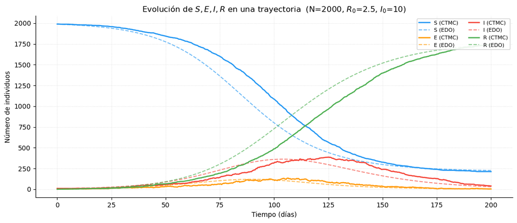

```
Pico CTMC: I_max =  387  (día 125)
Pico EDO:  I_max =  362  (día 104)
Tamaño final CTMC: R(T) = 1746  (87.3%)
Tamaño final EDO:  R(T) = 1741  (87.1%)
```

```python
import matplotlib.pyplot as plt
from scipy.integrate import solve_ivp


def seir_ode(R0, s0, e0, i0, t_grid):
    """Resuelve la EDO SEIR (en fracciones). Devuelve (s, e, i, r) en t_grid."""
    beta = beta_de(R0)
    def rhs(t, y):
        s, e, i, r = y
        return [
            -beta * s * i,
             beta * s * i - SIGMA * e,
             SIGMA * e - GAMMA * i,
             GAMMA * i,
        ]
    sol = solve_ivp(
        rhs, (t_grid[0], t_grid[-1]), [s0, e0, i0, 1 - s0 - e0 - i0],
        t_eval=t_grid, rtol=1e-8, atol=1e-10, method='RK45',
    )
    return sol.y


N      = 2000
R0     = 2.5
I0     = 10
T      = 200  # días, suficiente para ver subida, pico y bajada
t_grid = np.linspace(0, T, 600)

# Una trayectoria del CTMC
S_arr, E_arr, I_arr, R_arr = simular_seir(
    N=N, R0=R0, S0=N - I0, E0=0, I0=I0,
    t_grid=t_grid, semilla=42,
)
# EDO con las mismas condiciones iniciales (en fracción)
s_ode, e_ode, i_ode, r_ode = seir_ode(
    R0=R0, s0=(N - I0) / N, e0=0.0, i0=I0 / N, t_grid=t_grid,
)

fig, ax = plt.subplots(figsize=(11, 4.8))
for ctmc, ode, color, name in [
    (S_arr, s_ode * N, '#2196F3', 'S'),
    (E_arr, e_ode * N, '#FF9800', 'E'),
    (I_arr, i_ode * N, '#F44336', 'I'),
    (R_arr, r_ode * N, '#4CAF50', 'R'),
]:
    ax.plot(t_grid, ctmc, color=color, lw=1.8, label=f'{name} (CTMC)')
    ax.plot(t_grid, ode,  color=color, lw=1.4, ls='--', alpha=0.65,
            label=f'{name} (EDO)')

ax.set_xlabel('Tiempo (días)')
ax.set_ylabel('Número de individuos')
ax.set_title(f'Evolución de $S, E, I, R$ en una trayectoria  '
             f'(N={N}, $R_0$={R0}, $I_0$={I0})')
ax.legend(loc='upper right', framealpha=0.9, ncol=2, fontsize=8)
ax.grid(linestyle=':', alpha=0.4)
ax.spines[['top', 'right']].set_visible(False)
plt.tight_layout()
plt.show()

print(f'Pico CTMC: I_max = {I_arr.max():>4}  '
      f'(día {t_grid[I_arr.argmax()]:.0f})')
print(f'Pico EDO:  I_max = {(i_ode * N).max():>4.0f}  '
      f'(día {t_grid[(i_ode * N).argmax()]:.0f})')
print(f'Tamaño final CTMC: R(T) = {R_arr[-1]:>4}  ({100*R_arr[-1]/N:.1f}%)')
print(f'Tamaño final EDO:  R(T) = {r_ode[-1]*N:>4.0f}  ({100*r_ode[-1]:.1f}%)')
```

## Exploración interactiva del espacio de parámetros

La gráfica anterior compara una sola realización con la EDO en un punto fijo del espacio de parámetros. Para ver cómo cambia el panorama al variar el régimen y el tamaño, conviene un panel interactivo. Los sliders controlan:

- $R_0$: el régimen de transmisión.
- $N$: el tamaño de la población. Conforme $N$ crece, las realizaciones se concentran más alrededor de la EDO (las fluctuaciones decaen como $1/\sqrt{N}$); para $N$ pequeño la EDO ya no es una trayectoria típica.
- $I_0$: número inicial de infecciosos.
- $T$: horizonte temporal en días.
- Trayect.: cuántas realizaciones sobreponer en cada gráfica.

Cada cambio de slider genera una nueva tanda con semilla fresca.

```python
import ipywidgets as widgets
from IPython.display import display, clear_output


def panel_seir(R0_val, N_val, I0_val, T_val, n_paths):
    t_g = np.linspace(0, T_val, 400)
    s_o, e_o, i_o, r_o = seir_ode(
        R0=R0_val, s0=(N_val - I0_val)/N_val, e0=0.0,
        i0=I0_val/N_val, t_grid=t_g,
    )
    fig, ax = plt.subplots(figsize=(11, 4.5))
    rng = np.random.SeedSequence().generate_state(1)[0]
    for k in range(n_paths):
        _, _, I_arr, _ = simular_seir(
            N=N_val, R0=R0_val,
            S0=N_val - I0_val, E0=0, I0=I0_val,
            t_grid=t_g, semilla=int(rng) + k,
        )
        ax.plot(t_g, I_arr / N_val, color='#F44336', lw=0.6, alpha=0.3)
    ax.plot(t_g, i_o, color='black', lw=2.2, label='EDO determinista')
    ax.set_xlabel('Tiempo (días)')
    ax.set_ylabel('Fracción infecciosos $I_t / N$')
    ax.set_title(f'Panel SEIR: $R_0={R0_val}$,  N={N_val:,},  '
                 f'$I_0={I0_val}$,  {n_paths} trayect.')
    ax.legend(loc='upper right')
    ax.grid(linestyle=':', alpha=0.4)
    ax.spines[['top', 'right']].set_visible(False)
    plt.tight_layout()
    plt.show()


sl_R0 = widgets.FloatSlider(value=1.6, min=0.5, max=4.0, step=0.1,
                            description='$R_0$', continuous_update=False,
                            style={'description_width': '70px'},
                            layout=widgets.Layout(width='320px'))
sl_N  = widgets.IntSlider(value=2000, min=200, max=10000, step=200,
                          description='N', continuous_update=False,
                          style={'description_width': '70px'},
                          layout=widgets.Layout(width='320px'))
sl_I0 = widgets.IntSlider(value=5, min=1, max=50, step=1,
                          description='$I_0$', continuous_update=False,
                          style={'description_width': '70px'},
                          layout=widgets.Layout(width='320px'))
sl_T  = widgets.IntSlider(value=200, min=50, max=400, step=10,
                          description='T (días)', continuous_update=False,
                          style={'description_width': '70px'},
                          layout=widgets.Layout(width='320px'))
sl_K  = widgets.IntSlider(value=40, min=10, max=120, step=10,
                          description='Trayect.', continuous_update=False,
                          style={'description_width': '70px'},
                          layout=widgets.Layout(width='320px'))

out = widgets.Output()


def actualizar(_=None):
    with out:
        clear_output(wait=True)
        panel_seir(sl_R0.value, sl_N.value, sl_I0.value, sl_T.value, sl_K.value)


for sl in [sl_R0, sl_N, sl_I0, sl_T, sl_K]:
    sl.observe(actualizar, names='value')

col_izq = widgets.VBox([sl_R0, sl_N, sl_I0])
col_der = widgets.VBox([sl_T, sl_K])
controles = widgets.HBox([col_izq, col_der])
display(widgets.VBox([controles, out]))
actualizar()
```

```
VBox(children=(HBox(children=(VBox(children=(FloatSlider(value=1.6, continuous_update=False, description='$R_0…
```

## Extinción estocástica

Si $R_0 > 1$, la EDO siempre dice que la epidemia despega. El CTMC no: aun con $R_0 > 1$, los primeros infecciosos pueden recuperarse antes de contagiar a nadie, y la epidemia se apaga por azar.

### Aproximación por proceso de ramificación

Cuando $S \approx N$, cada infeccioso se comporta como una rama independiente que se reproduce a tasa $\beta$ y muere a tasa $\gamma$. Es un proceso de ramificación con razón $R_0 = \beta/\gamma$: la probabilidad de que una sola línea se extinga es $1/R_0$, y por independencia, partiendo de $I_0$ infecciosos,

$$ \mathbb{P}(\text{extinción}) \approx (1/R_0)^{I_0}. $$

La aproximación es exacta en el límite $N \to \infty$. La verificamos abajo.

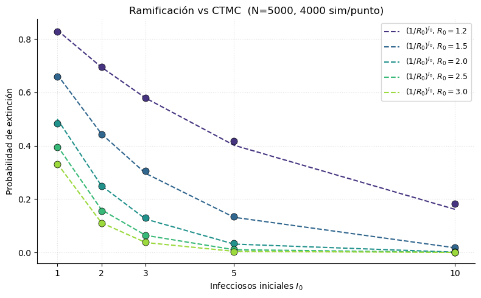

```python
@njit(cache=True)
def _extinct_kernel(N, beta, sigma, gamma, I0, umbral, seed):
    """0 si la epidemia se extingue (E=I=0); 1 si supera el umbral de despegue."""
    if seed >= 0:
        np.random.seed(seed)
    s, e, i, r = N - I0, 0, I0, 0
    while True:
        if e == 0 and i == 0:
            return 0
        if e + i + r >= umbral:
            return 1
        lam_SE = beta * s * i / N
        lam_EI = sigma * e
        lam_IR = gamma * i
        u = np.random.random() * (lam_SE + lam_EI + lam_IR)
        if u < lam_SE:
            s -= 1; e += 1
        elif u < lam_SE + lam_EI:
            e -= 1; i += 1
        else:
            i -= 1; r += 1


@njit(cache=True)
def proporcion_extincion(N, beta, sigma, gamma, I0, n_paths, seed):
    umbral = max(50, N // 20)        # 5% de la población o 50, lo que sea mayor
    ext = 0
    for k in range(n_paths):
        if _extinct_kernel(N, beta, sigma, gamma, I0, umbral, seed + k) == 0:
            ext += 1
    return ext / n_paths


N_EXT, N_PATHS_E = 5000, 4000
R0_GRID = np.array([1.2, 1.5, 2.0, 2.5, 3.0])
I0_GRID = np.array([1, 2, 3, 5, 10])

empirica = np.array([
    [proporcion_extincion(N_EXT, beta_de(R0v), SIGMA, GAMMA,
                          int(I0v), N_PATHS_E, 10 * a + b)
     for b, I0v in enumerate(I0_GRID)]
    for a, R0v in enumerate(R0_GRID)
])
teorica = (1.0 / R0_GRID[:, None]) ** I0_GRID[None, :]

fig, ax = plt.subplots(figsize=(8, 5))
colores = plt.cm.viridis(np.linspace(0.15, 0.85, R0_GRID.size))
for a, R0v in enumerate(R0_GRID):
    ax.plot(I0_GRID, teorica[a],  color=colores[a], lw=1.5, ls='--',
            label=f'$(1/R_0)^{{I_0}}$, $R_0={R0v}$')
    ax.plot(I0_GRID, empirica[a], 'o', color=colores[a], ms=8,
            markeredgecolor='black', markeredgewidth=0.5)
ax.set_xlabel('Infecciosos iniciales $I_0$')
ax.set_ylabel('Probabilidad de extinción')
ax.set_title(f'Ramificación vs CTMC  (N={N_EXT}, {N_PATHS_E} sim/punto)')
ax.set_xticks(I0_GRID)
ax.legend(loc='upper right', fontsize=9)
ax.grid(linestyle=':', alpha=0.4)
ax.spines[['top', 'right']].set_visible(False)
plt.tight_layout()
plt.show()
```

## Distribución del pico de infecciosos

La EDO predice un único pico: una altura y un día. La realidad es una distribución. Lo más relevante para planeación hospitalaria no es el promedio sino la cola: ¿con qué probabilidad el pico es 50% más alto del esperado? ¿Cuán incierto es el día del pico?

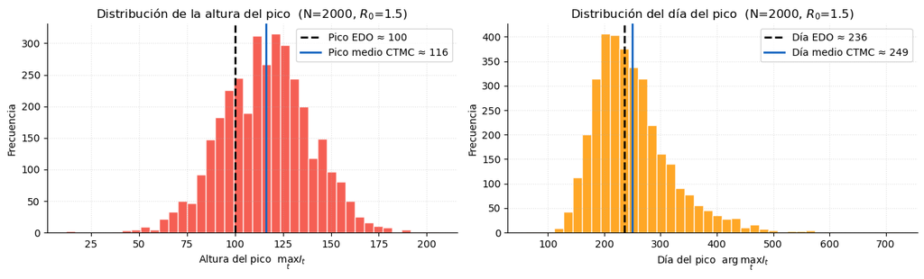

```
Simulaciones totales: 4000
Despegaron: 3459  (86.5%)
  de las cuales censuradas por T_max=1500: 0  (0.0% de las que despegaron)
Usadas en el histograma: 3459
Pico, media=116  mediana=117  sd=23
Día, media=249.5  mediana=236.6  sd=68.5
```

```python
@njit(cache=True)
def _seir_peak_kernel(N, beta, sigma, gamma, S0, E0, I0, R0_init, T_max, seed):
    """Devuelve (pico_I, dia_pico, R_final, terminada).
    terminada=1 si la epidemia se extinguió antes de T_max; 0 si quedó censurada
    por el horizonte temporal."""
    if seed >= 0:
        np.random.seed(seed)
    s, e, i, r = S0, E0, I0, R0_init
    t = 0.0
    pico_I = i
    dia_pico = 0.0
    while t < T_max:
        if e == 0 and i == 0:
            break
        rate_SE = beta * s * i / N
        rate_EI = sigma * e
        rate_IR = gamma * i
        lam = rate_SE + rate_EI + rate_IR
        u = np.random.random()
        if u <= 0.0:
            u = 1e-300
        t += -np.log(u) / lam
        u2 = np.random.random() * lam
        if u2 < rate_SE:
            s -= 1; e += 1
        elif u2 < rate_SE + rate_EI:
            e -= 1; i += 1
        else:
            i -= 1; r += 1
        if i > pico_I:
            pico_I = i
            dia_pico = t
    terminada = 1 if (e == 0 and i == 0) else 0
    return pico_I, dia_pico, r, terminada


@njit(cache=True)
def estadisticas_pico(N, beta, sigma, gamma, I0, n_paths, T_max, seed):
    R0_init = N - I0
    picos = np.empty(n_paths, dtype=np.float64)
    dias  = np.empty(n_paths, dtype=np.float64)
    finales = np.empty(n_paths, dtype=np.int64)
    completas = np.empty(n_paths, dtype=np.int64)
    for k in range(n_paths):
        p, d, rf, term = _seir_peak_kernel(N, beta, sigma, gamma,
                                           R0_init, 0, I0, 0,
                                           T_max, seed + k)
        picos[k] = p
        dias[k]  = d
        finales[k] = rf
        completas[k] = term
    return picos, dias, finales, completas


# Parámetros del experimento
N_PEAK   = 2000
R0_PEAK  = 1.5
I0_PEAK  = 5
N_SIMS   = 4000
T_PEAK   = 1500   # horizonte amplio para que las epidemias lentas terminen
beta_pk  = beta_de(R0_PEAK)

picos, dias, finales, completas = estadisticas_pico(
    N_PEAK, beta_pk, SIGMA, GAMMA, I0_PEAK, N_SIMS, T_PEAK, seed=0,
)

# Filtros: (1) la epidemia despegó (>5% de la población infectada al final)
#          (2) terminó dentro del horizonte (sin censura por T_max)
mascara_despego = finales > N_PEAK // 20
mascara_completa = completas == 1
mascara = mascara_despego & mascara_completa
picos_d = picos[mascara]
dias_d  = dias[mascara]

# Pico determinista (EDO) sobre un horizonte donde el pico es claramente visible
T_ODE = 300
t_fino = np.linspace(0, T_ODE, 4000)
s_o, e_o, i_o, r_o = seir_ode(R0=R0_PEAK,
                               s0=(N_PEAK - I0_PEAK)/N_PEAK,
                               e0=0.0, i0=I0_PEAK/N_PEAK,
                               t_grid=t_fino)
pico_ode  = i_o.max() * N_PEAK
dia_ode   = t_fino[i_o.argmax()]

fig, axes = plt.subplots(1, 2, figsize=(13, 4))

ax = axes[0]
ax.hist(picos_d, bins=40, color='#F44336', edgecolor='white', alpha=0.85)
ax.axvline(pico_ode, color='black', lw=2, ls='--',
           label=f'Pico EDO ≈ {pico_ode:.0f}')
ax.axvline(picos_d.mean(), color='#1565C0', lw=2,
           label=f'Pico medio CTMC ≈ {picos_d.mean():.0f}')
ax.set_xlabel('Altura del pico  $\\max_t I_t$')
ax.set_ylabel('Frecuencia')
ax.set_title(f'Distribución de la altura del pico  (N={N_PEAK}, $R_0$={R0_PEAK})')
ax.legend()
ax.grid(linestyle=':', alpha=0.4)
ax.spines[['top', 'right']].set_visible(False)

ax = axes[1]
ax.hist(dias_d, bins=40, color='#FF9800', edgecolor='white', alpha=0.85)
ax.axvline(dia_ode, color='black', lw=2, ls='--',
           label=f'Día EDO ≈ {dia_ode:.0f}')
ax.axvline(dias_d.mean(), color='#1565C0', lw=2,
           label=f'Día medio CTMC ≈ {dias_d.mean():.0f}')
ax.set_xlabel('Día del pico  $\\arg\\max_t I_t$')
ax.set_ylabel('Frecuencia')
ax.set_title(f'Distribución del día del pico  (N={N_PEAK}, $R_0$={R0_PEAK})')
ax.legend()
ax.grid(linestyle=':', alpha=0.4)
ax.spines[['top', 'right']].set_visible(False)

plt.tight_layout()
plt.show()

n_despego = int(mascara_despego.sum())
n_censura = int((mascara_despego & ~mascara_completa).sum())
print(f'Simulaciones totales: {N_SIMS}')
print(f'Despegaron: {n_despego}  ({100*n_despego/N_SIMS:.1f}%)')
print(f'  de las cuales censuradas por T_max={T_PEAK}: {n_censura}  '
      f'({100*n_censura/max(n_despego,1):.1f}% de las que despegaron)')
print(f'Usadas en el histograma: {mascara.sum()}')
print(f'Pico, media={picos_d.mean():.0f}  '
      f'mediana={np.median(picos_d):.0f}  '
      f'sd={picos_d.std():.0f}')
print(f'Día, media={dias_d.mean():.1f}  '
      f'mediana={np.median(dias_d):.1f}  '
      f'sd={dias_d.std():.1f}')
```

## ¿Qué decisiones puedo tomar con esto?

La distribución del pico no es un ejercicio académico: es lo que un planificador de salud pública usa para dimensionar capacidad. Dos preguntas concretas:

1. **¿Cuántas camas hospitalarias necesito?** No basta con la media: la cola superior (percentil 90 o 95 del pico) es lo que evita que el sistema se sature en el peor escenario plausible. La distribución estocástica te da ese número directamente; la EDO no.
2. **¿Cuánto reduce el pico una intervención?** Una medida que baja $R_0$ (de 2.5 a 2.0, por ejemplo, vía distanciamiento o mascarillas) traslada toda la distribución del pico hacia la izquierda. Comparar las distribuciones bajo distintos $R_0$ cuantifica el impacto real de la intervención, no sólo el cambio de la trayectoria promedio.

Abajo simulamos tres escenarios ($R_0 = 2.5, 2.0, 1.5$) y leemos los percentiles relevantes para planeación.

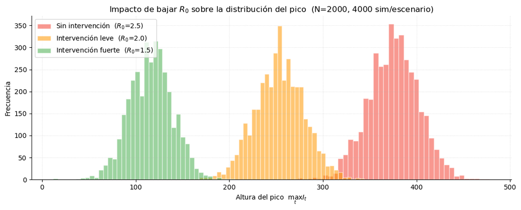

```
Cuantiles del pico (epidemias que despegaron y completaron):
     R0      n    Mediana     P90     P95     P99
    2.5   3954        376     409     419     437
    2.0   3868        254     287     296     315
    1.5   3459        117     146     154     170

Lectura: con N=2000, dimensionar al P95 da el número de camas con el que sólo 5% de las epidemias plausibles desbordan el sistema.
```

```python
escenarios = [
    (2.5, '#F44336', 'Sin intervención  ($R_0$=2.5)'),
    (2.0, '#FF9800', 'Intervención leve  ($R_0$=2.0)'),
    (1.5, '#4CAF50', 'Intervención fuerte  ($R_0$=1.5)'),
]

resultados = {}
for R0_v, _, _ in escenarios:
    p, d, fin, term = estadisticas_pico(
        N_PEAK, beta_de(R0_v), SIGMA, GAMMA, I0_PEAK, N_SIMS, T_PEAK, seed=0,
    )
    masc = (fin > N_PEAK // 20) & (term == 1)
    resultados[R0_v] = p[masc]

fig, ax = plt.subplots(figsize=(11, 4.5))
for R0_v, color, label in escenarios:
    p = resultados[R0_v]
    ax.hist(p, bins=40, color=color, edgecolor='white', alpha=0.55, label=label)
ax.set_xlabel('Altura del pico  $\\max_t I_t$')
ax.set_ylabel('Frecuencia')
ax.set_title(f'Impacto de bajar $R_0$ sobre la distribución del pico  '
             f'(N={N_PEAK}, {N_SIMS} sim/escenario)')
ax.legend()
ax.grid(linestyle=':', alpha=0.4)
ax.spines[['top', 'right']].set_visible(False)
plt.tight_layout()
plt.show()

print('Cuantiles del pico (epidemias que despegaron y completaron):')
print(f'  {"R0":>5}  {"n":>5}  {"Mediana":>9}  {"P90":>6}  {"P95":>6}  {"P99":>6}')
for R0_v, _, _ in escenarios:
    p = resultados[R0_v]
    print(f'  {R0_v:>5.1f}  {p.size:>5d}  {np.median(p):>9.0f}  '
          f'{np.percentile(p, 90):>6.0f}  {np.percentile(p, 95):>6.0f}  '
          f'{np.percentile(p, 99):>6.0f}')

print('\nLectura: con N=2000, dimensionar al P95 da el número de camas con el '
      'que sólo 5% de las epidemias plausibles desbordan el sistema.')
```

## Conclusiones

Las simulaciones anteriores ilustran tres tesis del marco CTMC aplicado al modelo SEIR:

1. **La EDO es el límite de población infinita.** A medida que $N$ crece, las trayectorias estocásticas que despegan se concentran alrededor de la EDO (con fluctuaciones que decaen como $1/\sqrt{N}$); para $N$ pequeño la varianza domina y la EDO ya no representa una trayectoria típica. Aun para $N$ grande, la EDO no es el promedio incondicional de las realizaciones, pues éstas son una mezcla de epidemias que se extinguen (planas) y epidemias que despegan (parecidas a la EDO).
2. **La extinción estocástica es invisible para la EDO.** Aun con $R_0 > 1$, una fracción $\bigl(1/R_0\bigr)^{I_0}$ de las epidemias se apagan por azar. Esta predicción, exacta en el límite, derivada del proceso de ramificación asociado al CTMC, es una aplicación directa de la teoría de procesos estocásticos que hemos visto, y es el tipo de información que un epidemiólogo necesita.
3. **La distribución del pico no es un punto.** La EDO da una sola cifra; el CTMC da una distribución completa. La cola superior de esa distribución, es decir, cuán alto puede ser el pico, es lo que determina la planeación hospitalaria, y simplemente no es derivable del modelo determinista.

## Referencias

1. S. M. Ross, *Introduction to Probability Models*. Academic Press, 1997.
2. P. Brémaud, *Probability Theory and Stochastic Processes*. Springer-Verlag, 2020.
3. D. T. Gillespie, "Exact stochastic simulation of coupled chemical reactions". *Journal of Physical Chemistry*, 81(25):2340-2361, 1977. Algoritmo de simulación de eventos usado en ambos cuadernos.
4. T. J. Sargent y J. Stachurski, *Modeling COVID 19 with Differential Equations*, QuantEcon (Julia lectures), https://julia.quantecon.org/continuous_time/seir_model.html. Fuente de los parámetros del modelo SEIR ($\sigma^{-1} \approx 5.2$ días, $\gamma^{-1} = 18$ días) y referencia del modelo determinista análogo.
5. Apuntes de clase del profesor Simón Lunagómez Coria, Procesos Estocásticos I, ITAM, 2026.